# Bayesian GLM Part2

# 7 Model validation

**rstanarm**

**pp check**

Post predictive checks provide additional diagnostics about the fit of the model. Specifically, they provide a comparison between predictions drawn from the model and the observed data used to train the model.

**See list of available diagnostics by name**

```r
available_ppc()
```

```
bayesplot PPC module:
  ppc_bars
  ppc_bars_grouped
  ppc_boxplot
  ppc_dens
  ppc_dens_overlay
  ppc_dens_overlay_grouped
  ppc_dots
  ppc_ecdf_overlay
  ppc_ecdf_overlay_grouped
  ppc_error_binned
  ppc_error_hist
  ppc_error_hist_grouped
  ppc_error_scatter
  ppc_error_scatter_avg
  ppc_error_scatter_avg_grouped
  ppc_error_scatter_avg_vs_x
  ppc_freqpoly
  ppc_freqpoly_grouped
  ppc_hist
  ppc_intervals
  ppc_intervals_grouped
  ppc_km_overlay
  ppc_km_overlay_grouped
  ppc_loo_intervals
  ppc_loo_pit_ecdf
  ppc_loo_pit_overlay
  ppc_loo_pit_qq
  ppc_loo_ribbon
  ppc_pit_ecdf
  ppc_pit_ecdf_grouped
  ppc_ribbon
  ppc_ribbon_grouped
  ppc_rootogram
  ppc_scatter
  ppc_scatter_avg
  ppc_scatter_avg_grouped
  ppc_stat
  ppc_stat_2d
  ppc_stat_freqpoly
  ppc_stat_freqpoly_grouped
  ppc_stat_grouped
  ppc_violin_grouped
```

- dens_overlay: plots the density distribution of the observed data (black line) overlayed on top of 50 density distributions generated from draws from the model (light blue). Ideally, the 50 realisations should be roughly consistent with the observed data.

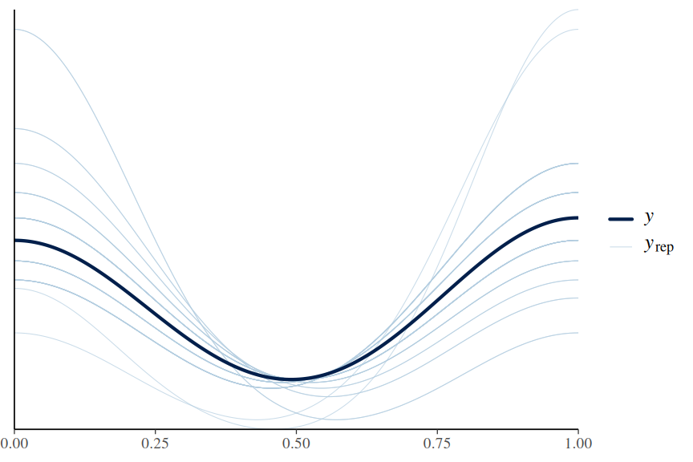

```r
pp_check(polis.rstanarm3, plotfun = "dens_overlay")
```

The model draws appear to be consistent with the observed data.

- error_scatter_avg: this plots the observed values against the average residuals. Similar to a residual plot, we do not want to see any patterns in this plot. That said, these are not overly interpretable for models involving binary data.

```r
# pp_check(polis.rstanarm3, plotfun='error_scatter_avg')
```

This is not interpretable.

- error_scatter_avg_vs_x: this is similar to a regular residual plot and as such should be interpreted as such. Again, this is not interpretable for binary data.

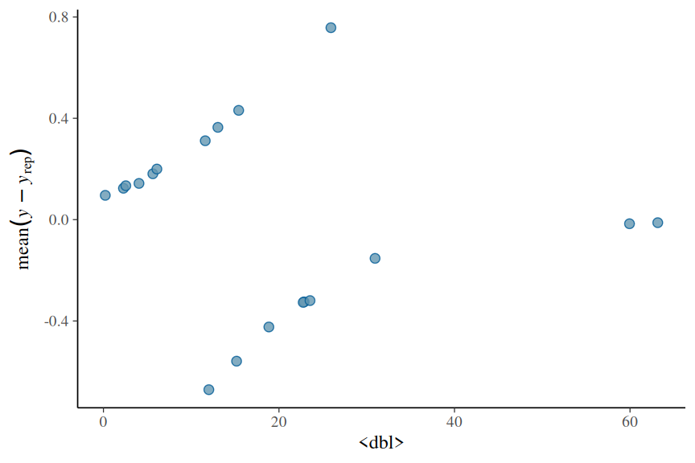

```r
pp_check(polis.rstanarm3, x = polis$RATIO, plotfun = "error_scatter_avg_vs_x")
```

- intervals: plots the observed data overlayed on top of posterior predictions associated with each level of the predictor. Ideally, the observed data should all fall within the predictive intervals.

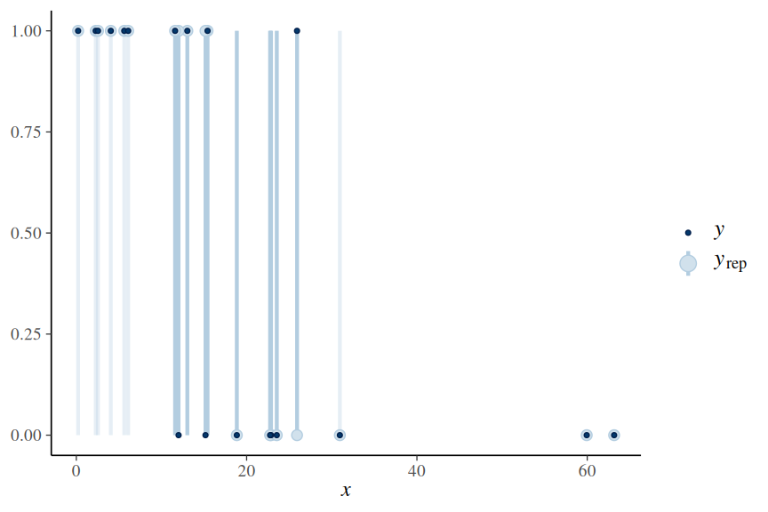

```r
pp_check(polis.rstanarm3, x = polis$RATIO, plotfun = "intervals")
```

The modelled predictions are mostly consistent with the observed data. There is really only one exception.

- ribbon: this is just an alternative way of expressing the above plot.

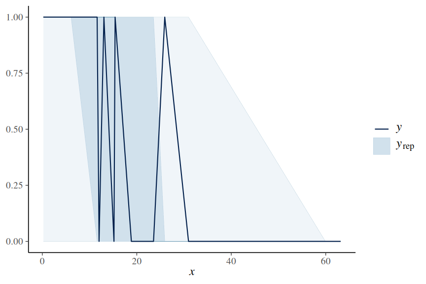

```r
pp_check(polis.rstanarm3, x = polis$RATIO, plotfun = "ribbon")
```

The `shinystan` package allows the full suite of MCMC diagnostics and posterior predictive checks to be accessed via a web interface.

```r
# library(shinystan)
# launch_shinystan(polis.rstanarm3)
```

**DHARMa residuals**

DHARMa residuals provide very useful diagnostics. Unfortunately, we cannot directly use the `simulateResiduals()` function to generate the simulated residuals. However, if we are willing to calculate some of the components yourself, we can still obtain the simulated residuals from the fitted stan model.

We need to supply:

- simulated (predicted) responses associated with each observation.
- observed values
- fitted (predicted) responses (averaged) associated with each observation

```
 DHARMa: qgam was unable to calculate quantile regression for quantile 0.25. Possibly to few (unique) data points / predictions. The quantile will be ommited in plots and significance calculations.
```

```
 DHARMa: qgam was unable to calculate quantile regression for quantile 0.5. Possibly to few (unique) data points / predictions. The quantile will be ommited in plots and significance calculations.
```

```
 DHARMa: qgam was unable to calculate quantile regression for quantile 0.75. Possibly to few (unique) data points / predictions. The quantile will be ommited in plots and significance calculations.
```

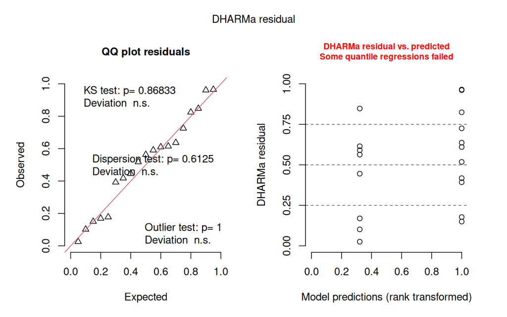

```r
preds <- posterior_predict(polis.rstanarm3, ndraws = 250, summary = FALSE)
polis.resids <- createDHARMa(
  simulatedResponse = t(preds),
  observedResponse = polis$PA,
  fittedPredictedResponse = apply(preds, 2, median),
  integerResponse = TRUE
)
plot(polis.resids)
```

**Conclusions:**

- the simulated residuals do not suggest any issues with the residuals
- there is no evidence of a lack of fit.

**brms**

**pp check**

Post predictive checks provide additional diagnostics about the fit of the model. Specifically, they provide a comparison between predictions drawn from the model and the observed data used to train the model.

**See list of available diagnostics by name**

```r
available_ppc()
```

```
bayesplot PPC module:
  ppc_bars
  ppc_bars_grouped
  ppc_boxplot
  ppc_dens
  ppc_dens_overlay
  ppc_dens_overlay_grouped
  ppc_dots
  ppc_ecdf_overlay
  ppc_ecdf_overlay_grouped
  ppc_error_binned
  ppc_error_hist
  ppc_error_hist_grouped
  ppc_error_scatter
  ppc_error_scatter_avg
  ppc_error_scatter_avg_grouped
  ppc_error_scatter_avg_vs_x
  ppc_freqpoly
  ppc_freqpoly_grouped
  ppc_hist
  ppc_intervals
  ppc_intervals_grouped
  ppc_km_overlay
  ppc_km_overlay_grouped
  ppc_loo_intervals
  ppc_loo_pit_ecdf
  ppc_loo_pit_overlay
  ppc_loo_pit_qq
  ppc_loo_ribbon
  ppc_pit_ecdf
  ppc_pit_ecdf_grouped
  ppc_ribbon
  ppc_ribbon_grouped
  ppc_rootogram
  ppc_scatter
  ppc_scatter_avg
  ppc_scatter_avg_grouped
  ppc_stat
  ppc_stat_2d
  ppc_stat_freqpoly
  ppc_stat_freqpoly_grouped
  ppc_stat_grouped
  ppc_violin_grouped
```

- dens_overlay: plots the density distribution of the observed data (black line) overlayed on top of 50 density distributions generated from draws from the model (light blue). Ideally, the 50 realisations should be roughly consistent with the observed data.

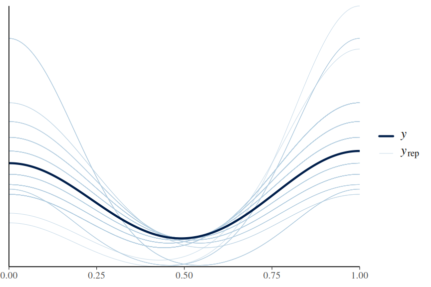

```r
polis_brm3 |> pp_check(type = "dens_overlay", ndraws = 100)
```

The model draws appear to be consistent with the observed data.

- error_scatter_avg: this plots the observed values against the average residuals. Similar to a residual plot, we do not want to see any patterns in this plot. Note, this is not really that useful for models that involve a binomial response

```r
## polis_brm3 |> pp_check(type = 'error_scatter_avg')
```

This is not really interpretable

- error_scatter_avg_vs_x: this is similar to a regular residual plot and as such should be interpreted as such. This is not easy to interpret for binomial responses.

```
Using all posterior draws for ppc type 'error_scatter_avg_vs_x' by default.
```

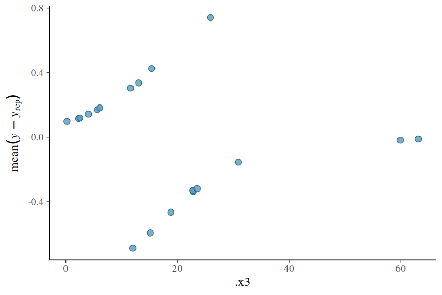

```r
polis_brm3 |> pp_check(x = "RATIO", type = "error_scatter_avg_vs_x")
```

- intervals: plots the observed data overlayed on top of posterior predictions associated with each level of the predictor. Ideally, the observed data should all fall within the predictive intervals.

```
Using all posterior draws for ppc type 'intervals' by default.
```

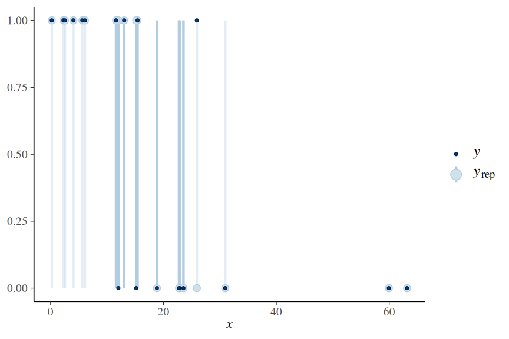

```r
polis_brm3 |> pp_check(x = "RATIO", type = "intervals")
```

- ribbon: this is just an alternative way of expressing the above plot.

```
Using all posterior draws for ppc type 'ribbon' by default.
```

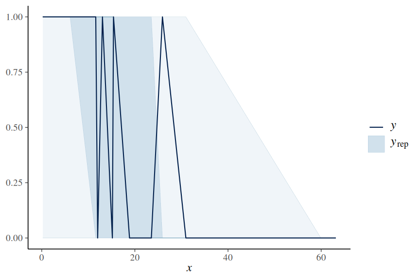

```r
polis_brm3 |> pp_check(x = "RATIO", type = "ribbon")
```

The `shinystan` package allows the full suite of MCMC diagnostics and posterior predictive checks to be accessed via a web interface.

```r
# library(shinystan)
# launch_shinystan(polis_brm3)
```

**DHARMa residuals**

DHARMa residuals provide very useful diagnostics. Unfortunately, we cannot directly use the `simulateResiduals()` function to generate the simulated residuals. However, if we are willing to calculate some of the components yourself, we can still obtain the simulated residuals from the fitted stan model.

We need to supply:

- simulated (predicted) responses associated with each observation.
- observed values
- fitted (predicted) responses (averaged) associated with each observation

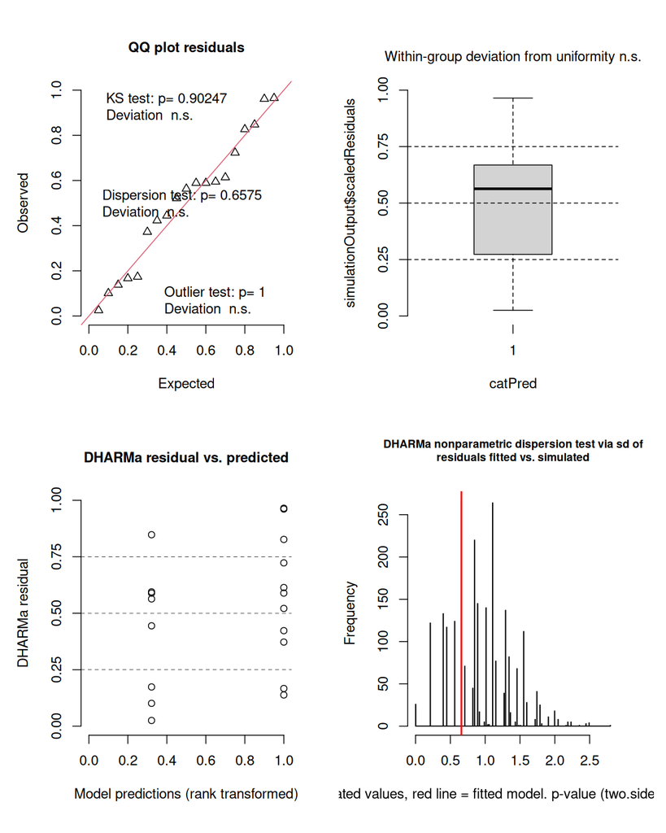

```r
polis.resids <- make_brms_dharma_res(polis_brm3, integerResponse = FALSE)
wrap_elements(~ testUniformity(polis.resids)) +
  wrap_elements(~ plotResiduals(polis.resids, form = factor(rep(1, nrow(polis))))) +
  wrap_elements(~ plotResiduals(polis.resids, quantreg = FALSE)) +
  wrap_elements(~ testDispersion(polis.resids))
```

**Conclusions:**

- the simulated residuals do not suggest any issues with the residuals
- there is no evidence of a lack of fit.

Here is the old (and now incorrect) way…

```
 DHARMa: qgam was unable to calculate quantile regression for quantile 0.25. Possibly to few (unique) data points / predictions. The quantile will be ommited in plots and significance calculations.
```

```
 DHARMa: qgam was unable to calculate quantile regression for quantile 0.5. Possibly to few (unique) data points / predictions. The quantile will be ommited in plots and significance calculations.
```

```
 DHARMa: qgam was unable to calculate quantile regression for quantile 0.75. Possibly to few (unique) data points / predictions. The quantile will be ommited in plots and significance calculations.
```

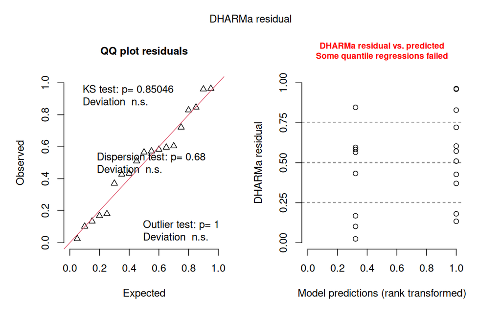

```r
preds <- polis_brm3 |> posterior_predict(ndraws = 250, summary = FALSE)
polis.resids <- createDHARMa(
  simulatedResponse = t(preds),
  observedResponse = polis$PA,
  fittedPredictedResponse = apply(preds, 2, median),
  integerResponse = TRUE
)
polis.resids |> plot()
```

# 8 Partial effects plots

**rstanarm**

**ggpredict**

```
Data points may overlap. Use the `jitter` argument to add some amount of
  random variation to the location of data points and avoid overplotting.
```

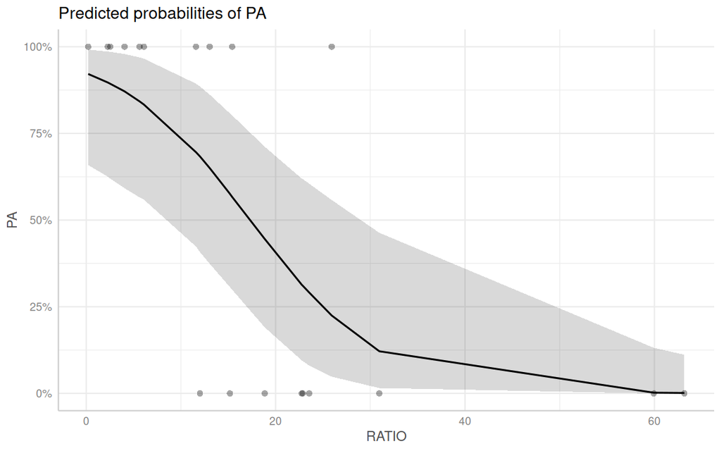

```r
polis.rstanarm3 |>
  ggpredict() |>
  plot(show_data = TRUE, jitter = FALSE)
```

**ggemmeans**

```
Data points may overlap. Use the `jitter` argument to add some amount of
  random variation to the location of data points and avoid overplotting.
```

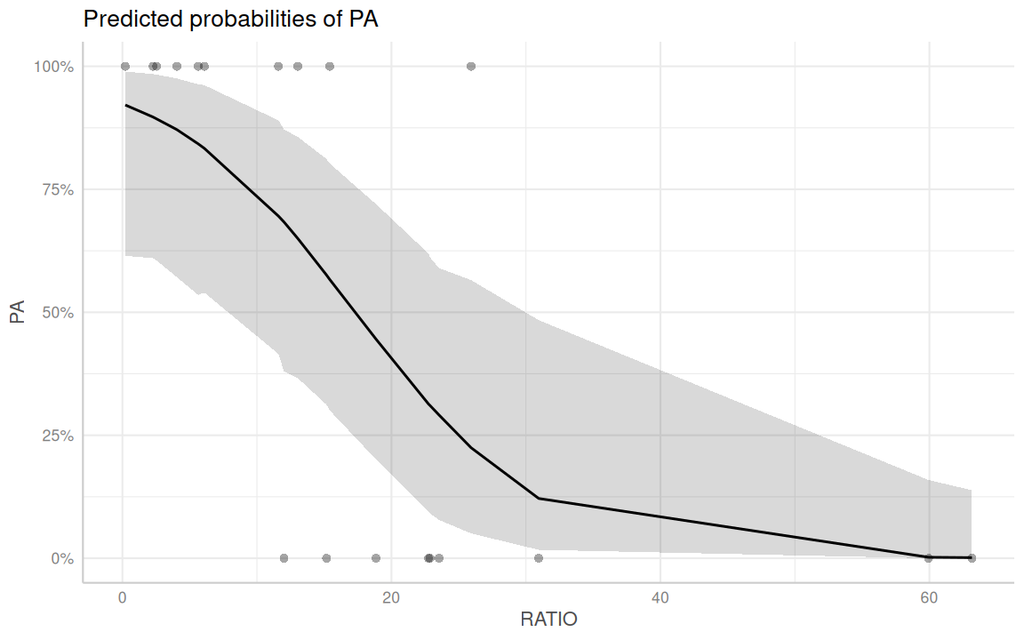

```r
polis.rstanarm3 |>
  ggemmeans(~RATIO) |>
  plot(show_data = TRUE)
```

**epred_draws**

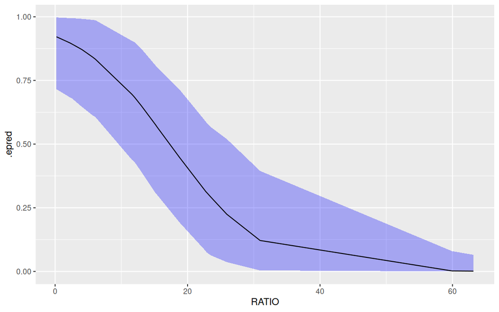

```r
polis.rstanarm3 |>
  epred_draws(newdata = polis) |>
  median_hdci() |>
  ggplot(aes(x = RATIO, y = .epred)) +
  geom_ribbon(aes(ymin = .lower, ymax = .upper), fill = "blue", alpha = 0.3) +
  geom_line()
```

**brms**

**conditional_effects**

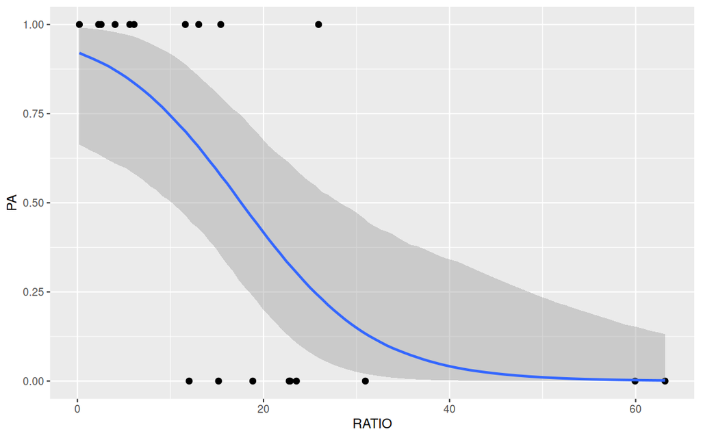

```r
polis_brm3 |>
  conditional_effects() |>
  plot(points = TRUE)
```

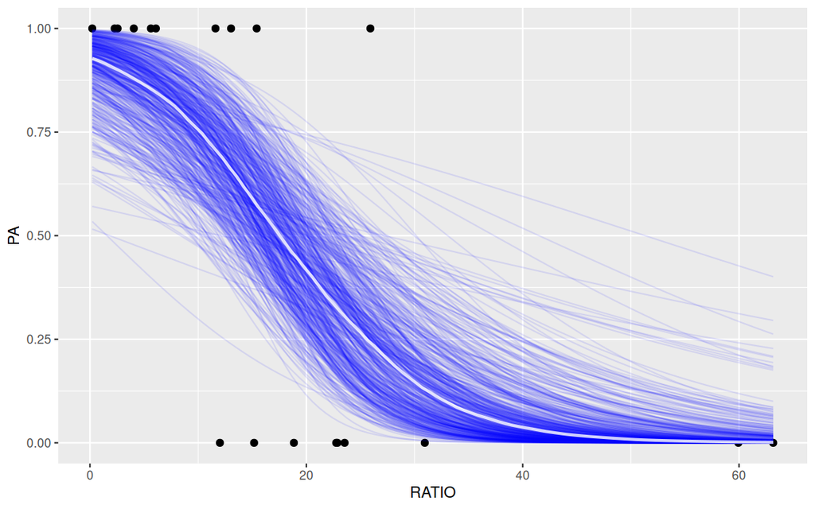

```r
polis_brm3 |>
  conditional_effects(spaghetti = TRUE, ndraws = 500) |>
  plot(points = TRUE)
```

**ggpredict**

```
Data points may overlap. Use the `jitter` argument to add some amount of
  random variation to the location of data points and avoid overplotting.
```

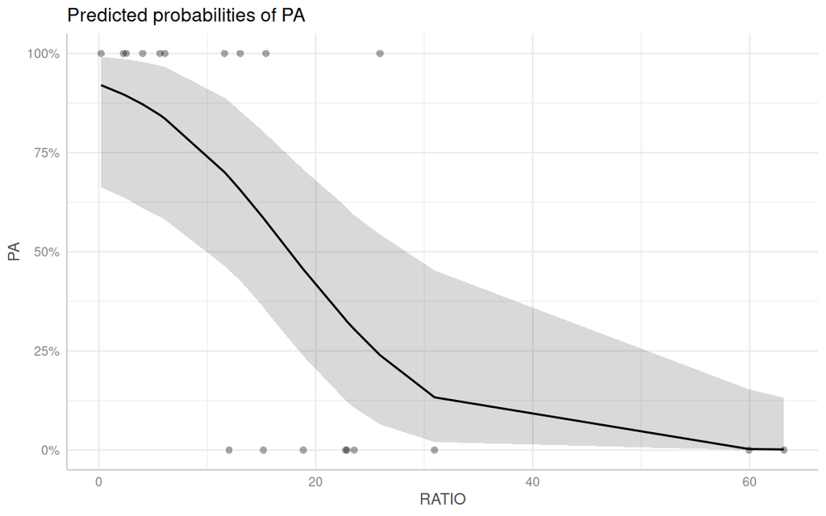

```r
polis_brm3 |>
  ggpredict() |>
  plot(show_data = TRUE, jitter = FALSE)
```

**ggemmeans**

```
Data points may overlap. Use the `jitter` argument to add some amount of
  random variation to the location of data points and avoid overplotting.
```

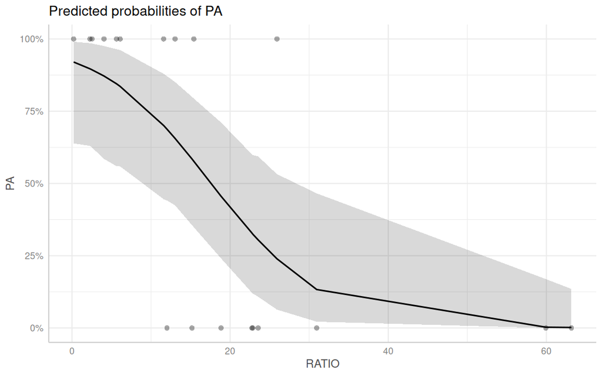

```r
polis_brm3 |>
  ggemmeans(~RATIO) |>
  plot(show_data = TRUE)
```

**epred_draws**

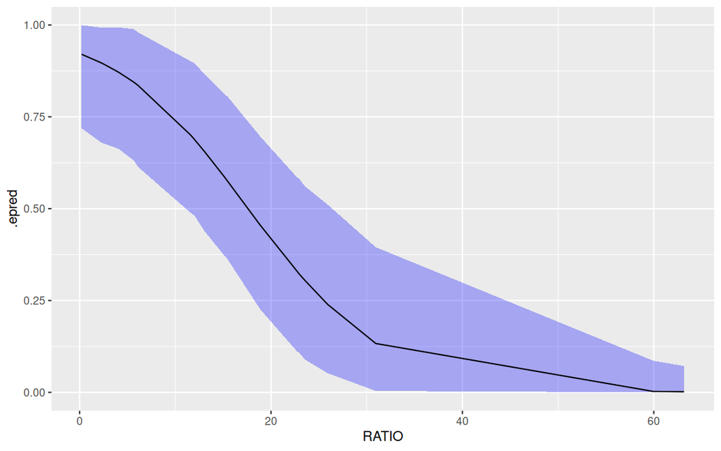

```r
polis_brm3 |>
  epred_draws(newdata = polis) |>
  median_hdci() |>
  ggplot(aes(x = RATIO, y = .epred)) +
  geom_ribbon(aes(ymin = .lower, ymax = .upper), fill = "blue", alpha = 0.3) +
  geom_line()
```

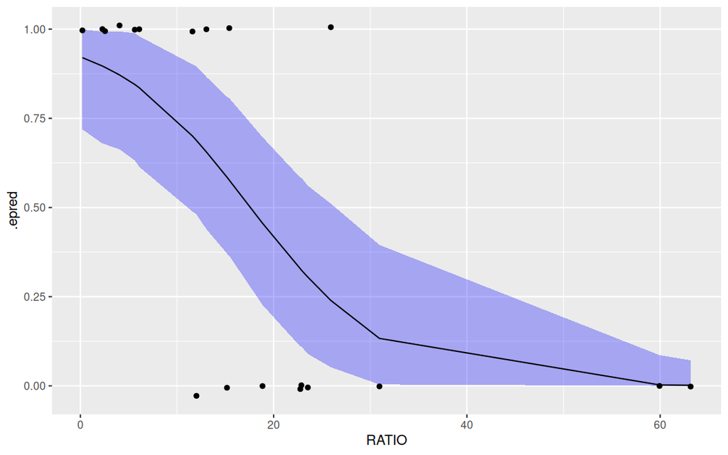

```r
partial.obs <- polis |>
  mutate(
    fit = fitted(polis_brm3, newdata = polis)[, "Estimate"],
    resid = resid(polis_brm3)[, "Estimate"],
    Obs = fit + resid
  )

polis_brm3 |>
  epred_draws(newdata = polis) |>
  median_hdci() |>
  ggplot(aes(x = RATIO, y = .epred)) +
  geom_ribbon(aes(ymin = .lower, ymax = .upper), fill = "blue", alpha = 0.3) +
  geom_point(data = partial.obs, aes(y = Obs)) +
  geom_line()
```

# 9 Model investigation

**rstanarm**

**summary**

The `summary()` method generates simple summaries (mean, standard deviation as well as 10, 50 and 90 percentiles).

```r
summary(polis.rstanarm3)
```

```
Model Info:
 function:     stan_glm
 family:       binomial [logit]
 formula:      PA ~ RATIO
 algorithm:    sampling
 sample:       2400 (posterior sample size)
 priors:       see help('prior_summary')
 observations: 19
 predictors:   2

Estimates:
              mean   sd   10%   50%   90%
(Intercept)  2.6    1.1  1.3   2.5   4.0
RATIO       -0.1    0.1 -0.2  -0.1  -0.1

Fit Diagnostics:
           mean   sd   10%   50%   90%
mean_PPD 0.5    0.1  0.4   0.5   0.7

The mean_ppd is the sample average posterior predictive distribution of the outcome variable (for details see help('summary.stanreg')).

MCMC diagnostics
              mcse Rhat n_eff
(Intercept)   0.0  1.0  2116
RATIO         0.0  1.0  2210
mean_PPD      0.0  1.0  2148
log-posterior 0.0  1.0  2297

For each parameter, mcse is Monte Carlo standard error, n_eff is a crude measure of effective sample size, and Rhat is the potential scale reduction factor on split chains (at convergence Rhat=1).
```

**Conclusions:**

**summarise_draws (posterior)**

```r
polis.rstanarm3$stanfit |>
  summarise_draws(
    median,
    HDInterval::hdi,
    rhat, length, ess_bulk, ess_tail
  )
```

```
# A tibble: 4 × 8
  variable       median   lower    upper  rhat length ess_bulk ess_tail
  <chr>           <dbl>   <dbl>    <dbl> <dbl>  <dbl>    <dbl>    <dbl>
1 (Intercept)     2.49    0.634   4.73   1.000   2400    2129.    2177.
2 RATIO          -0.144  -0.264  -0.0484 1.00    2400    2233.    2177.
3 mean_PPD        0.526   0.263   0.737  1.00    2400    2172.    2263.
4 log-posterior -11.9   -14.3   -11.2    1.00    2400    2309.    2283.
```

We can also alter the CI level.

```r
polis.rstanarm3$stanfit |>
  summarise_draws(
    median,
    ~ HDInterval::hdi(.x, credMass = 0.9),
    rhat, length, ess_bulk, ess_tail
  )
```

```
# A tibble: 4 × 8
  variable       median   lower    upper  rhat length ess_bulk ess_tail
  <chr>           <dbl>   <dbl>    <dbl> <dbl>  <dbl>    <dbl>    <dbl>
1 (Intercept)     2.49    0.863   4.28   1.000   2400    2129.    2177.
2 RATIO          -0.144  -0.234  -0.0530 1.00    2400    2233.    2177.
3 mean_PPD        0.526   0.368   0.737  1.00    2400    2172.    2263.
4 log-posterior -11.9   -13.5   -11.2    1.00    2400    2309.    2283.
```

**tidyMCMC**

```r
tidyMCMC(polis.rstanarm3$stanfit,
  estimate.method = "median", conf.int = TRUE,
  conf.method = "HPDinterval", rhat = TRUE, ess = TRUE
)
```

```
# A tibble: 4 × 7
  term          estimate std.error conf.low conf.high  rhat   ess
  <chr>            <dbl>     <dbl>    <dbl>     <dbl> <dbl> <int>
1 (Intercept)      2.56     1.07      0.634    4.73   1.00   2116
2 RATIO           -0.148    0.0568   -0.264   -0.0484 0.999  2210
3 mean_PPD         0.529    0.123     0.263    0.737  1.00   2148
4 log-posterior  -12.2      1.04    -14.3    -11.2    1.00   2297
```

**Conclusions:**

**as_draws_df (posterior)**

```r
polis.rstanarm3$stanfit |> as_draws_df()
```

```
# A draws_df: 800 iterations, 3 chains, and 4 variables
   (Intercept)  RATIO mean_PPD log-posterior
1          1.5 -0.044     0.63           -14
2          3.2 -0.156     0.63           -12
3          2.6 -0.170     0.47           -12
4          1.5 -0.118     0.37           -12
5          1.2 -0.075     0.32           -12
6          2.2 -0.141     0.53           -11
7          1.2 -0.088     0.47           -12
8          1.7 -0.086     0.63           -12
9          2.1 -0.079     0.63           -13
10         1.7 -0.074     0.42           -12
# ... with 2390 more draws
# ... hidden reserved variables {'.chain', '.iteration', '.draw'}
```

```r
## summarised
polis.rstanarm3$stanfit |>
  as_draws_df() |>
  summarise_draws(
    "median",
    ~ HDInterval::hdi(.x),
    "rhat",
    "ess_bulk"
  )
```

```
# A tibble: 4 × 6
  variable       median   lower    upper  rhat ess_bulk
  <chr>           <dbl>   <dbl>    <dbl> <dbl>    <dbl>
1 (Intercept)     2.49    0.634   4.73   1.000    2129.
2 RATIO          -0.144  -0.264  -0.0484 1.00     2233.
3 mean_PPD        0.526   0.263   0.737  1.00     2172.
4 log-posterior -11.9   -14.3   -11.2    1.00     2309.
```

```r
## summarised on fractional scale
polis.rstanarm3$stanfit |>
  as_draws_df() |>
  mutate(across(everything(), exp)) |>
  summarise_draws(
    "median",
    ~ HDInterval::hdi(.x),
    "rhat",
    "ess_bulk"
  )
```

```
# A tibble: 4 × 6
  variable           median        lower      upper  rhat ess_bulk
  <chr>               <dbl>        <dbl>      <dbl> <dbl>    <dbl>
1 (Intercept)   12.1        0.744        84.0       1.000    2129.
2 RATIO          0.866      0.768         0.953     1.00     2233.
3 mean_PPD       1.69       1.30          2.09      1.00     2172.
4 log-posterior  0.00000660 0.0000000784  0.0000126 1.00     2309.
```

**gather_draws**

```r
polis.draw <- polis.rstanarm3 |> gather_draws(`(Intercept)`, RATIO)
## OR via regex
polis.draw <- polis.rstanarm3 |> gather_draws(`.Intercept.*|RATIO.*`, regex = TRUE)
polis.draw
```

```
# A tibble: 4,800 × 5
# Groups:   .variable [2]
   .chain .iteration .draw .variable   .value
    <int>      <int> <int> <chr>        <dbl>
 1      1          1     1 (Intercept)   1.48
 2      1          2     2 (Intercept)   3.16
 3      1          3     3 (Intercept)   2.58
 4      1          4     4 (Intercept)   1.48
 5      1          5     5 (Intercept)   1.21
 6      1          6     6 (Intercept)   2.23
 7      1          7     7 (Intercept)   1.22
 8      1          8     8 (Intercept)   1.74
 9      1          9     9 (Intercept)   2.12
10      1         10    10 (Intercept)   1.73
# ℹ 4,790 more rows
```

We can then summarise this

```r
polis.draw |> median_hdci()
```

```
# A tibble: 2 × 7
  .variable   .value .lower  .upper .width .point .interval
  <chr>        <dbl>  <dbl>   <dbl>  <dbl> <chr>  <chr>
1 (Intercept)  2.49   0.634  4.73     0.95 median hdci
2 RATIO       -0.144 -0.265 -0.0496   0.95 median hdci
```